# Predicting Customer Satisfaction

## Project scope

This project is about doing factor analysis and running regression model to predict customer satisfaction based on the market segment dataset.

The outline of the study includes

1. Reading the dataset and checking for any data quality issues
2. Do some variable analysis
3. Build the regression model (Without worrying about correlations)
4. Interpret the model
5. Check for correlations
6. Do factor analysis if needed and extract factors
7. Run the regression on the factor dataset
8. Compare the naive model to the model with factors

```r
# Reading the csv file 'Factor-Hair-Revised.csv'

factor_hair_raw <- read.csv('Factor-Hair-Revised.csv')
print(head(factor_hair_raw))
```

```
##   ID ProdQual Ecom TechSup CompRes Advertising ProdLine SalesFImage
## 1  1      8.5  3.9     2.5     5.9         4.8      4.9         6.0
## 2  2      8.2  2.7     5.1     7.2         3.4      7.9         3.1
## 3  3      9.2  3.4     5.6     5.6         5.4      7.4         5.8
## 4  4      6.4  3.3     7.0     3.7         4.7      4.7         4.5
## 5  5      9.0  3.4     5.2     4.6         2.2      6.0         4.5
## 6  6      6.5  2.8     3.1     4.1         4.0      4.3         3.7
##   ComPricing WartyClaim OrdBilling DelSpeed Satisfaction
## 1        6.8        4.7        5.0      3.7          8.2
## 2        5.3        5.5        3.9      4.9          5.7
## 3        4.5        6.2        5.4      4.5          8.9
## 4        8.8        7.0        4.3      3.0          4.8
## 5        6.8        6.1        4.5      3.5          7.1
## 6        8.5        5.1        3.6      3.3          4.7
```

```r
# Removing the id column
factor_hair_raw <- factor_hair_raw[,c(2:13)]
print(head(factor_hair_raw))
```

```
##   ProdQual Ecom TechSup CompRes Advertising ProdLine SalesFImage
## 1      8.5  3.9     2.5     5.9         4.8      4.9         6.0
## 2      8.2  2.7     5.1     7.2         3.4      7.9         3.1
## 3      9.2  3.4     5.6     5.6         5.4      7.4         5.8
## 4      6.4  3.3     7.0     3.7         4.7      4.7         4.5
## 5      9.0  3.4     5.2     4.6         2.2      6.0         4.5
## 6      6.5  2.8     3.1     4.1         4.0      4.3         3.7
##   ComPricing WartyClaim OrdBilling DelSpeed Satisfaction
## 1        6.8        4.7        5.0      3.7          8.2
## 2        5.3        5.5        3.9      4.9          5.7
## 3        4.5        6.2        5.4      4.5          8.9
## 4        8.8        7.0        4.3      3.0          4.8
## 5        6.8        6.1        4.5      3.5          7.1
## 6        8.5        5.1        3.6      3.3          4.7
```

Upon observing the data type from above table, all the variables seem to be continuous. So, no dummy coding is required for this analysis

```r
# Looking at the summary statistics
summary(factor_hair_raw)
```

```
##     ProdQual           Ecom          TechSup         CompRes
##  Min.   : 5.000   Min.   :2.200   Min.   :1.300   Min.   :2.600
##  1st Qu.: 6.575   1st Qu.:3.275   1st Qu.:4.250   1st Qu.:4.600
##  Median : 8.000   Median :3.600   Median :5.400   Median :5.450
##  Mean   : 7.810   Mean   :3.672   Mean   :5.365   Mean   :5.442
##  3rd Qu.: 9.100   3rd Qu.:3.925   3rd Qu.:6.625   3rd Qu.:6.325
##  Max.   :10.000   Max.   :5.700   Max.   :8.500   Max.   :7.800
##   Advertising       ProdLine      SalesFImage      ComPricing
##  Min.   :1.900   Min.   :2.300   Min.   :2.900   Min.   :3.700
##  1st Qu.:3.175   1st Qu.:4.700   1st Qu.:4.500   1st Qu.:5.875
##  Median :4.000   Median :5.750   Median :4.900   Median :7.100
##  Mean   :4.010   Mean   :5.805   Mean   :5.123   Mean   :6.974
##  3rd Qu.:4.800   3rd Qu.:6.800   3rd Qu.:5.800   3rd Qu.:8.400
##  Max.   :6.500   Max.   :8.400   Max.   :8.200   Max.   :9.900
##    WartyClaim      OrdBilling       DelSpeed      Satisfaction
##  Min.   :4.100   Min.   :2.000   Min.   :1.600   Min.   :4.700
##  1st Qu.:5.400   1st Qu.:3.700   1st Qu.:3.400   1st Qu.:6.000
##  Median :6.100   Median :4.400   Median :3.900   Median :7.050
##  Mean   :6.043   Mean   :4.278   Mean   :3.886   Mean   :6.918
##  3rd Qu.:6.600   3rd Qu.:4.800   3rd Qu.:4.425   3rd Qu.:7.625
##  Max.   :8.100   Max.   :6.700   Max.   :5.500   Max.   :9.900
```

```r
# As the independent variable for the analysis is Satisfaction, creating a separate dataframe for the dependent variables. This is useful for easily doing feature scaling and centering. Helps in improving the data quality
dependent_raw <- factor_hair_raw[,c(1:11)]
# Even though most of the fatures seem to be on a similar scale, some of the features has max value 5.7 and some of them has 9.9. This is almost 40% different. So doing feature scaling helps in ignoring the units of measurements of each feature and helps in better model interpretation.
dependent_scaled <- data.frame(lapply(dependent_raw, function(x) scale(x, center = FALSE, scale = max(x, na.rm = FALSE)/10)))
summary(dependent_scaled)
```

```
##     ProdQual           Ecom           TechSup          CompRes
##  Min.   : 5.000   Min.   : 3.860   Min.   : 1.529   Min.   : 3.333
##  1st Qu.: 6.575   1st Qu.: 5.746   1st Qu.: 5.000   1st Qu.: 5.897
##  Median : 8.000   Median : 6.316   Median : 6.353   Median : 6.987
##  Mean   : 7.810   Mean   : 6.442   Mean   : 6.312   Mean   : 6.977
##  3rd Qu.: 9.100   3rd Qu.: 6.886   3rd Qu.: 7.794   3rd Qu.: 8.109
##  Max.   :10.000   Max.   :10.000   Max.   :10.000   Max.   :10.000
##   Advertising        ProdLine       SalesFImage       ComPricing
##  Min.   : 2.923   Min.   : 2.738   Min.   : 3.537   Min.   : 3.737
##  1st Qu.: 4.885   1st Qu.: 5.595   1st Qu.: 5.488   1st Qu.: 5.934
##  Median : 6.154   Median : 6.845   Median : 5.976   Median : 7.172
##  Mean   : 6.169   Mean   : 6.911   Mean   : 6.248   Mean   : 7.044
##  3rd Qu.: 7.385   3rd Qu.: 8.095   3rd Qu.: 7.073   3rd Qu.: 8.485
##  Max.   :10.000   Max.   :10.000   Max.   :10.000   Max.   :10.000
##    WartyClaim       OrdBilling        DelSpeed
##  Min.   : 5.062   Min.   : 2.985   Min.   : 2.909
##  1st Qu.: 6.667   1st Qu.: 5.522   1st Qu.: 6.182
##  Median : 7.531   Median : 6.567   Median : 7.091
##  Mean   : 7.460   Mean   : 6.385   Mean   : 7.065
##  3rd Qu.: 8.148   3rd Qu.: 7.164   3rd Qu.: 8.045
##  Max.   :10.000   Max.   :10.000   Max.   :10.000
```

[figure not shown]

```r
# Adding the independent column back to the scaled dataframe
factor_hair_scaled <- dependent_scaled
factor_hair_scaled[,c(12)] <-factor_hair_raw[,c(12)]
names(factor_hair_scaled)[12]<-'Satisfaction'
print(head(factor_hair_scaled))
```

```
##   ProdQual     Ecom  TechSup  CompRes Advertising ProdLine SalesFImage
## 1      8.5 6.842105 2.941176 7.564103    7.384615 5.833333    7.317073
## 2      8.2 4.736842 6.000000 9.230769    5.230769 9.404762    3.780488
## 3      9.2 5.964912 6.588235 7.179487    8.307692 8.809524    7.073171
## 4      6.4 5.789474 8.235294 4.743590    7.230769 5.595238    5.487805
## 5      9.0 5.964912 6.117647 5.897436    3.384615 7.142857    5.487805
## 6      6.5 4.912281 3.647059 5.256410    6.153846 5.119048    4.512195
##   ComPricing WartyClaim OrdBilling DelSpeed Satisfaction
## 1   6.868687   5.802469   7.462687 6.727273          8.2
## 2   5.353535   6.790123   5.820896 8.909091          5.7
## 3   4.545455   7.654321   8.059701 8.181818          8.9
## 4   8.888889   8.641975   6.417910 5.454545          4.8
## 5   6.868687   7.530864   6.716418 6.363636          7.1
## 6   8.585859   6.296296   5.373134 6.000000          4.7
```

```r
# RUnning the regression model for every column
lm_func <- function(y) {
  model <- lm(Satisfaction ~ y, data = factor_hair_scaled)
  summary(model)
}
lapply(factor_hair_scaled[,1:11], lm_func)
```

```
## $ProdQual
##
## Call:
## lm(formula = Satisfaction ~ y, data = factor_hair_scaled)
##
## Residuals:
##      Min       1Q   Median       3Q      Max
## -1.88746 -0.72711 -0.01577  0.85641  2.25220
##
## Coefficients:
##             Estimate Std. Error t value Pr(>|t|)
## (Intercept)  3.67593    0.59765   6.151 1.68e-08 ***
## y            0.41512    0.07534   5.510 2.90e-07 ***
## ---
## Signif. codes:  0 '***' 0.001 '**' 0.01 '*' 0.05 '.' 0.1 ' ' 1
##
## Residual standard error: 1.047 on 98 degrees of freedom
## Multiple R-squared:  0.2365, Adjusted R-squared:  0.2287
## F-statistic: 30.36 on 1 and 98 DF,  p-value: 2.901e-07
##
##
## $Ecom
##
## Call:
## lm(formula = Satisfaction ~ y, data = factor_hair_scaled)
##
## Residuals:
##      Min       1Q   Median       3Q      Max
## -2.37200 -0.78971  0.04959  0.68085  2.34580
##
## Coefficients:
##             Estimate Std. Error t value Pr(>|t|)
## (Intercept)  5.15157    0.61614   8.361 4.28e-13 ***
## y            0.27420    0.09397   2.918  0.00437 **
## ---
## Signif. codes:  0 '***' 0.001 '**' 0.01 '*' 0.05 '.' 0.1 ' ' 1
##
## Residual standard error: 1.149 on 98 degrees of freedom
## Multiple R-squared:  0.07994,    Adjusted R-squared:  0.07056
## F-statistic: 8.515 on 1 and 98 DF,  p-value: 0.004368
```

[output cut: 174 more lines]

```
##
## Residuals:
##      Min       1Q   Median       3Q      Max
## -2.22475 -0.54846  0.08796  0.54462  2.59432
##
## Coefficients:
##             Estimate Std. Error t value Pr(>|t|)
## (Intercept)  3.27907    0.52938   6.194 1.38e-08 ***
## y            0.51503    0.07363   6.994 3.30e-10 ***
## ---
## Signif. codes:  0 '***' 0.001 '**' 0.01 '*' 0.05 '.' 0.1 ' ' 1
##
## Residual standard error: 0.9783 on 98 degrees of freedom
## Multiple R-squared:  0.333,  Adjusted R-squared:  0.3262
## F-statistic: 48.92 on 1 and 98 DF,  p-value: 3.3e-10
```

```r
attach(factor_hair_scaled)
# Building a modelby combining all the features
# Checking the naive model without verifying the correlation of the dependent variables.
naive_model <- lm(Satisfaction~.,factor_hair_scaled)
summary(naive_model)
```

```
##
## Call:
## lm(formula = Satisfaction ~ ., data = factor_hair_scaled)
##
## Residuals:
##      Min       1Q   Median       3Q      Max
## -1.43005 -0.31165  0.07621  0.37190  0.90120
##
## Coefficients:
##             Estimate Std. Error t value Pr(>|t|)
## (Intercept) -0.66961    0.81233  -0.824  0.41199
## ProdQual     0.37137    0.05177   7.173 2.18e-10 ***
## Ecom        -0.25112    0.07636  -3.289  0.00145 **
## TechSup      0.02804    0.05416   0.518  0.60591
## CompRes      0.13029    0.07935   1.642  0.10416
## Advertising -0.01691    0.04004  -0.422  0.67382
## ProdLine     0.11788    0.06741   1.749  0.08384 .
## SalesFImage  0.66101    0.08015   8.247 1.45e-12 ***
## ComPricing  -0.03814    0.04631  -0.824  0.41235
## WartyClaim  -0.08342    0.09988  -0.835  0.40587
## OrdBilling   0.09805    0.06946   1.412  0.16160
## DelSpeed     0.09113    0.10804   0.844  0.40124
## ---
## Signif. codes:  0 '***' 0.001 '**' 0.01 '*' 0.05 '.' 0.1 ' ' 1
##
## Residual standard error: 0.5623 on 88 degrees of freedom
## Multiple R-squared:  0.8021, Adjusted R-squared:  0.7774
## F-statistic: 32.43 on 11 and 88 DF,  p-value: < 2.2e-16
```

When combining all the columns, r2 value is improved by huge margin. Only 3 columns ‘ProdQual’, ‘Ecom’, ‘SalesFImage’ are contributing to the predictive power of the independent variable.

There could be two reasons for it.

1. The other features are realy not predictive enough
2. There can be a great amount of multicollinearity, which is affecting the columns.

However, the above naive model didn’t validate the basic assumption of multi collinearity linear regression.

```r
# Checking if there is any correlation between the variables.
library(reshape2)
factor_hair_cor <- cor(factor_hair_scaled)
melted_cor <- melt(factor_hair_cor)
```

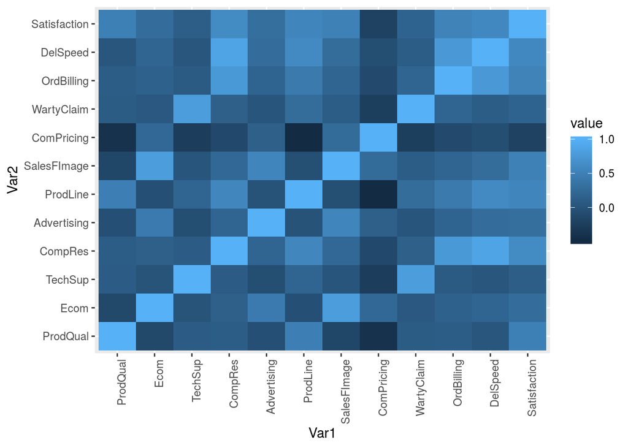

```r
# Plotting the hearmap of the correlations
library(ggplot2)
ggplot(data = melted_cor, aes(x=Var1, y=Var2, fill=value)) +
  geom_tile() +
  theme(axis.text.x=element_text(angle=90,hjust=1))
```

On careful observation of the heatmap, there are patterns of strong correlation between few variables. 1. Ecom, SalesFImage 2. TechSup, WartyClaim 3. CompRes, DelSpeed 4. CompRes, OrdBilling

As there are multiple variables which has high correlation, the underlying assumption of all uncorrelated variables is void. Hence, linear regression cannot be done with the given variables in their current form. This leads to explore the possibility of PCA and factor analysis.

```r
# Checking the possibility of dimenionality reduction

library(psych)
dependent_corr <- cor(dependent_scaled)
print(cortest.bartlett(dependent_corr,nrow(dependent_scaled)))
```

```
## $chisq
## [1] 619.2726
##
## $p.value
## [1] 1.79337e-96
##
## $df
## [1] 55
```

The p-value of the test is within the significant limit (assuming aplha=0.5) There is a possibility of PCA and dimension reduction

```r
# Finding out eigen values and eigen vectors
dep_eigen <- eigen(dependent_corr)
dep_eigen_val <- dep_eigen$values
dep_eigen_vectors <- dep_eigen$vectors

print(dep_eigen_val)
```

```
##  [1] 3.42697133 2.55089671 1.69097648 1.08655606 0.60942409 0.55188378
##  [7] 0.40151815 0.24695154 0.20355327 0.13284158 0.09842702
```

The requirement of the project is to consider 4 principal components. Selecting eigen values greater than 1 will select 4 from the above list

```r
# Loadings and communality
pc <- principal(r=dependent_scaled, nfactors = 4, rotate = 'varimax')
pc
```

```
## Principal Components Analysis
## Call: principal(r = dependent_scaled, nfactors = 4, rotate = "varimax")
## Standardized loadings (pattern matrix) based upon correlation matrix
##               RC1   RC2   RC3   RC4   h2    u2 com
## ProdQual     0.00 -0.01 -0.03  0.88 0.77 0.232 1.0
## Ecom         0.06  0.87  0.05 -0.12 0.78 0.223 1.1
## TechSup      0.02 -0.02  0.94  0.10 0.89 0.107 1.0
## CompRes      0.93  0.12  0.05  0.09 0.88 0.119 1.1
## Advertising  0.14  0.74 -0.08  0.01 0.58 0.424 1.1
## ProdLine     0.59 -0.06  0.15  0.64 0.79 0.213 2.1
## SalesFImage  0.13  0.90  0.08 -0.16 0.86 0.141 1.1
## ComPricing  -0.09  0.23 -0.25 -0.72 0.64 0.359 1.5
## WartyClaim   0.11  0.05  0.93  0.10 0.89 0.108 1.1
## OrdBilling   0.86  0.11  0.08  0.04 0.77 0.234 1.1
## DelSpeed     0.94  0.18  0.00  0.05 0.91 0.086 1.1
##
##                        RC1  RC2  RC3  RC4
## SS loadings           2.89 2.23 1.86 1.77
## Proportion Var        0.26 0.20 0.17 0.16
## Cumulative Var        0.26 0.47 0.63 0.80
## Proportion Explained  0.33 0.26 0.21 0.20
## Cumulative Proportion 0.33 0.59 0.80 1.00
##
## Mean item complexity =  1.2
## Test of the hypothesis that 4 components are sufficient.
##
## The root mean square of the residuals (RMSR) is  0.06
##  with the empirical chi square  39.02  with prob <  0.0018
##
## Fit based upon off diagonal values = 0.97
```

By carefully observing the above factors RC1 has high values for CompRes, OrdBilling, DelSpeed. All of them are related to ease of using and customer service. Hence, it is safe to name this as ‘ServiceQuality’ RC2 has high values of Ecom and SalesFImage and Advertising. This component can be named as ‘Marketing’ RC3 has highest values for TechSup, WartyClaim. This component explains the importance of after sales support. Naming this as ‘CustomerSupport’ RC4 has high values for ProdQual and also negative relation to CompPricing. So, it is evident that this component has importance to Quality and least importance to pricing. It si safe to name is ‘ProductQuality’

To summarize RC1 - ServiceQuality RC2 - Marketing RC3 - CustomerSupport RC4 - ProductQuality

Next step is to perform linear regresssion onm the components

```r
# Before performing the linear regression, combining Principal component scores and the independent variable to a dataframe
pca_factor_hair <- data.frame(pc$scores)
colnames(pca_factor_hair) <- c('ServiceQuality','Marketing','CustomerSupport','ProductQuality')
pca_factor_hair
```

```
##     ServiceQuality   Marketing CustomerSupport ProductQuality
## 1       0.12749104  0.76986860    -1.878446273     0.36648477
## 2       1.22166663 -1.64586166    -0.614030010     0.81306481
## 3       0.61582140  0.58000368     0.003689252     1.56997685
## 4      -0.84462665 -0.27192183     1.267493254    -1.25416452
## 5      -0.31979430 -0.83406501    -0.008096627     0.44753766
## 6      -0.64702925 -1.06726829    -1.303198892    -1.05277921
## 7      -2.62679851 -0.24588272    -0.555423494    -1.22601470
## 8      -0.27936394 -0.15732039    -0.749311481    -1.01464175
## 9       1.05151341 -0.17228834    -0.092252815    -1.65809634
## 10      0.42875382  0.76353272    -0.450377116    -0.89116595
## 11     -0.13580761 -0.76759698    -0.463706767     0.60634140
## 12     -1.45030579  1.35959912     0.437785016    -1.06981053
## 13      0.62461823  2.11311565    -0.168284409     0.87466736
## 14      0.42724294 -0.40405102     0.432245882     0.90236591
```

[output cut: 86 more lines]

```r
pca_factor_hair[,c(5)] <- factor_hair_raw[,c(12)]
names(pca_factor_hair)[5]<-'Satisfaction'
pca_factor_hair
```

```
##     ServiceQuality   Marketing CustomerSupport ProductQuality Satisfaction
## 1       0.12749104  0.76986860    -1.878446273     0.36648477          8.2
## 2       1.22166663 -1.64586166    -0.614030010     0.81306481          5.7
## 3       0.61582140  0.58000368     0.003689252     1.56997685          8.9
## 4      -0.84462665 -0.27192183     1.267493254    -1.25416452          4.8
## 5      -0.31979430 -0.83406501    -0.008096627     0.44753766          7.1
## 6      -0.64702925 -1.06726829    -1.303198892    -1.05277921          4.7
## 7      -2.62679851 -0.24588272    -0.555423494    -1.22601470          5.7
## 8      -0.27936394 -0.15732039    -0.749311481    -1.01464175          6.3
## 9       1.05151341 -0.17228834    -0.092252815    -1.65809634          7.0
## 10      0.42875382  0.76353272    -0.450377116    -0.89116595          5.5
## 11     -0.13580761 -0.76759698    -0.463706767     0.60634140          7.4
## 12     -1.45030579  1.35959912     0.437785016    -1.06981053          6.0
## 13      0.62461823  2.11311565    -0.168284409     0.87466736          8.4
## 14      0.42724294 -0.40405102     0.432245882     0.90236591          7.6
```

[output cut: 86 more lines]

Performing linear regression

```r
final_model <- lm(Satisfaction~.,pca_factor_hair)
summary(final_model)
```

```
##
## Call:
## lm(formula = Satisfaction ~ ., data = pca_factor_hair)
##
## Residuals:
##     Min      1Q  Median      3Q     Max
## -1.6308 -0.4996  0.1372  0.4623  1.5228
##
## Coefficients:
##                 Estimate Std. Error t value Pr(>|t|)
## (Intercept)      6.91800    0.07089  97.589  < 2e-16 ***
## ServiceQuality   0.61805    0.07125   8.675 1.12e-13 ***
## Marketing        0.50973    0.07125   7.155 1.74e-10 ***
## CustomerSupport  0.06714    0.07125   0.942    0.348
## ProductQuality   0.54032    0.07125   7.584 2.24e-11 ***
## ---
## Signif. codes:  0 '***' 0.001 '**' 0.01 '*' 0.05 '.' 0.1 ' ' 1
##
## Residual standard error: 0.7089 on 95 degrees of freedom
## Multiple R-squared:  0.6605, Adjusted R-squared:  0.6462
## F-statistic: 46.21 on 4 and 95 DF,  p-value: < 2.2e-16
```

## Final Model Interpretation

The final model has 3 variables contributing to the prediction. CustomerSupport is not contributing to the model r2 is 0.66 and adj r2 is 0.6462 means the components are helping 64.6% of the independent variable.

Even though the final model r2 is much lesser than the naive model before pca, as the variables are much less correlated to each other, the final model is more powerful than the naive model before pca.

tuning some of the hyperparameters and minimizing errors and using some of the optimization algorithms helps in improving the model accuracy. But not performing all of them as they are out of this mini project’s scope.